# Final Exam

Author

Abhiram Naredla

Published

April 27, 2023

# Obtaining the data

```r
load("twoMillion311calls.RData")
library(tidyverse)
library(lubridate)
df <- select(df, CreatedDate, ClosedDate,Agency, AgencyName,ComplaintType,Descriptor,Borough,IncidentZip)
df <- df |> distinct()
df$responsetime <- as.integer(mdy_hms(df$ClosedDate) - mdy_hms(df$CreatedDate))
df <- df |> drop_na()
df <- df[df$responsetime>0,]
```

```r
dim(df)
```

```
[1] 1419955       9
```

My main data frame consists of about 1.4 million rows and 9 relevant columns. I will analyze this data set.

## Part 1: Numerical Description

```r
#Plot 1
df |> count(AgencyName,sort=TRUE)
```

```
# A tibble: 930 × 2
   AgencyName                                              n
   <chr>                                               <int>
 1 Department of Housing Preservation and Development 490478
 2 New York City Police Department                    223680
 3 Department of Transportation                       195916
 4 Department of Environmental Protection             144745
 5 Department of Buildings                             71477
 6 Department of Parks and Recreation                  68491
 7 Department of Health and Mental Hygiene             32113
 8 Department of Consumer Affairs                      22815
 9 Taxi and Limousine Commission                       22628
10 Department of Sanitation                            12182
# … with 920 more rows
```

This Count function table shows the names of the Agencies that received the most complaints sorted from most complaints to least complaints (top 10 Agencies).

```r
#Plot 2
summary(df$responsetime)
```

```
     Min.   1st Qu.    Median      Mean   3rd Qu.      Max.
        1     36251    259249   1601887    950400 269148616
```

This statistical summary of the response time variable shows the mean, median, quartiles, etc for the response time (in seconds) of each complaint in the data set. As shown, the mean response time is skewed by many upper outliers in the data set and is very far away from the median response time.

```r
#Plot 3
with(df, table(Borough))
```

```
Borough
        BRONX      BROOKLYN     MANHATTAN        QUEENS STATEN ISLAND
       210223        402866        266052        322807         72093
  Unspecified
       145914
```

This table shows the number of complaints by Borough in the data set. Brooklyn is the Borough that has the most complaints and Staten Island has the least.

```r
#Plot 4
df |> count(ComplaintType,sort=TRUE)
```

```
# A tibble: 195 × 2
   ComplaintType             n
   <chr>                 <int>
 1 HEATING              122288
 2 GENERAL CONSTRUCTION  94652
 3 Street Condition      83976
 4 PLUMBING              81877
 5 Blocked Driveway      69442
 6 PAINT - PLASTER       63547
 7 Water System          55463
 8 NONCONST              48623
 9 Illegal Parking       47122
10 Sewer                 37909
# … with 185 more rows
```

This count table of Complaint Type shows the top 10 most common types of complaints in the data set. Heating is the most common type of complaint by a good margin.

```r
#Plot 5
dfa <- subset(df,Borough %in% c("BRONX","BROOKLYN","MANHATTAN","QUEENS","STATEN ISLAND"))
dfb <- subset(dfa,ComplaintType %in% c("HEATING","GENERAL CONSTRUCTION","Street Condition","Blocked Driveway"))
table(dfb$Borough,dfb$ComplaintType)
```

```
                Blocked Driveway GENERAL CONSTRUCTION HEATING Street Condition
  BRONX                    10623                20029   22291             9269
  BROOKLYN                 25650                24791   26091            23799
  MANHATTAN                 2129                11464   19076            17590
  QUEENS                   28834                 7478   12835            22960
  STATEN ISLAND             2206                 1550    1143            10358
```

This contingency table between Borough and Complaint Type shows the number of each type of complaint type (four most frequent complaint types) by Borough. Some notable trends deduced from this table are that Brooklyn has an even spread of all complaint types, ‘Heating’ is the most frequent type of complaint in Manhattan and ‘Blocked Driveway’ is the most frequent type of complaint in Queens.

```r
#Plot 6
df_t <- df %>%
    group_by(AgencyName) %>%
    summarize(AverageResponseTime = round(mean(responsetime)/86400)) %>%
    arrange(desc(AverageResponseTime))
head(df_t,10)
```

```
# A tibble: 10 × 2
   AgencyName                                        AverageResponseTime
   <chr>                                                           <dbl>
 1 311 Quality Assurance                                            1129
 2 School - IS 093 Ridgewood                                         640
 3 School - PS 41 New Dorp                                           630
 4 School - PS 21 Philip H Sheridan                                  584
 5 School - PS 65 The Academy of Innovative Learning                 564
 6 School - Harlem Success Academy I Charter School                  563
 7 School - Health Professions and Human Services                    563
 8 School - PS 226 - Bronx                                           558
 9 School - The Anderson School                                      529
10 School - PS 196                                                   527
```

This table shows the Agencies that take the most time to deal with a complaint - here the average response time is measured in days. The Agency ‘311 Quality Assurance’ takes a whopping 1129 days on average to deal with a complaint.

```r
#Plot 7
df_y <- dfa %>%
    group_by(Borough) %>%
    summarize(AverageResponseTime = round(mean(responsetime)/86400)) %>%
    arrange(AverageResponseTime)
df_y
```

```
# A tibble: 5 × 2
  Borough       AverageResponseTime
  <chr>                       <dbl>
1 BROOKLYN                       17
2 BRONX                          19
3 QUEENS                         19
4 MANHATTAN                      21
5 STATEN ISLAND                  25
```

This table shows the Average response time for a complaint grouped by Borough - average response time is in days. It shows that on average, complaints in Brooklyn last 17 days and complaints in Staten Island last 25 days.

## Part 2: Visual Description

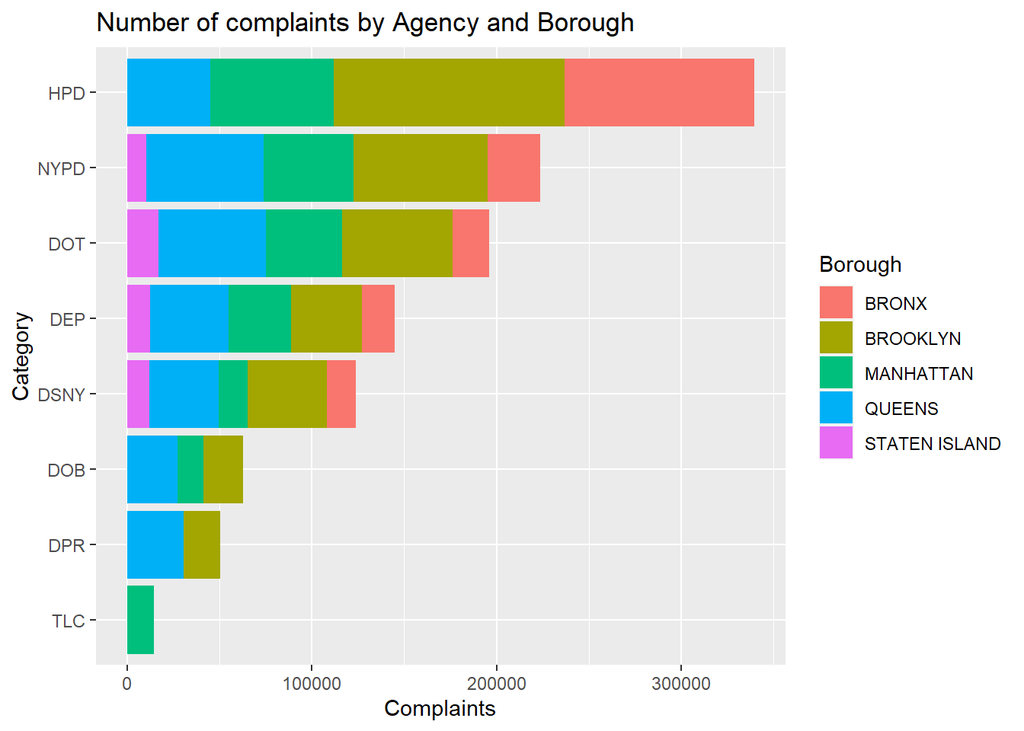

```r
#PLot 1
options(scipen = 999)

df7 <- dfa |>
  group_by(Agency,Borough) |>
  subset(select=c(Agency,Borough)) |>
  summarize(Complaints = n()) |>
  filter(Complaints > 10000)

df8 <- df7 |>
  group_by(Agency) |>
  summarize(totComplaints=sum(Complaints))
df9 <- full_join(df7,df8)
df9 |>
  ggplot(aes(x=reorder(Agency,totComplaints),y=Complaints,fill=Borough)) +
  xlab("Category") +
  geom_bar(stat="identity") +
  coord_flip() +
  ggtitle("Number of complaints by Agency and Borough")
```

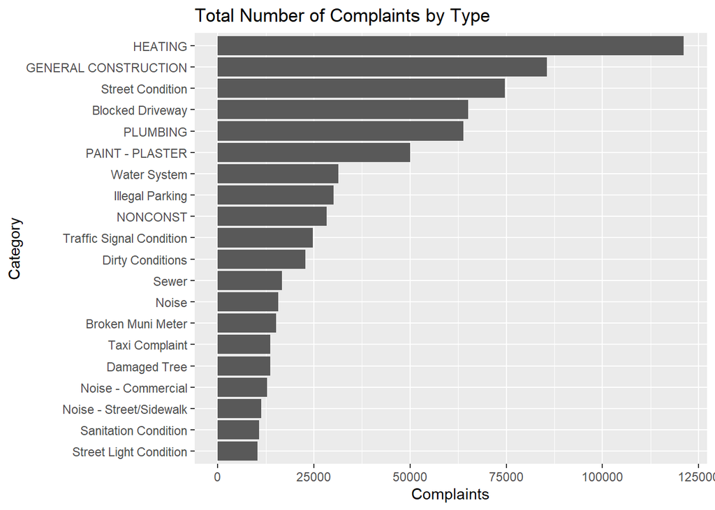

```r
#Plot 2
df1 <- df |>
  group_by(ComplaintType,Borough) |>
  subset(select=c(ComplaintType,Borough)) |>
  summarize(Complaints = n()) |>
  filter(Complaints > 10000)

df2 <- df1 |>
  group_by(ComplaintType) |>
  summarize(totComplaints=sum(Complaints))
df3 <- full_join(df1,df2)

df3 |>
  ggplot(aes(x=reorder(ComplaintType,totComplaints),y=Complaints)) +
  xlab("Category") +
  geom_bar(stat="identity") +
  coord_flip() +
  ggtitle("Total Number of Complaints by Type")
```

This bar plot shows that Heating was by far the most frequent type of complaint in the data set followed by General Construction and Street Condition.

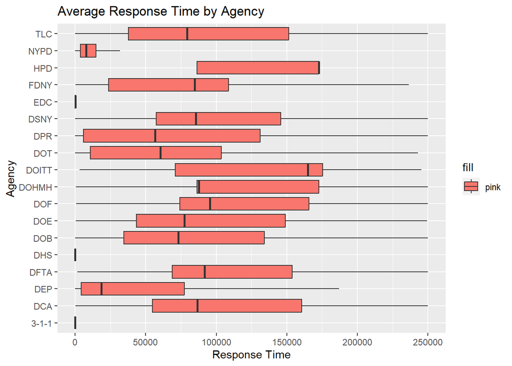

```r
#Plot 3
df %>%
    ggplot(aes(x=Agency,y=responsetime,group=Agency,fill='pink')) +
    geom_boxplot(outlier.shape = NA) +
    labs(title = "Average Response Time by Agency",
         x = "Agency",
         y = "Response Time") +
    ylim(0,250000) +
    coord_flip()
```

```r
    scale_fill_manual(values = "pink")
```

[output not shown]

This box plot shows the average response time by Agency. It shows that Agencies like NYPD and DEP take a much shorter time to handle complaints compared to the other agencies, and agencies like HPD and DOITT take a much longer time.

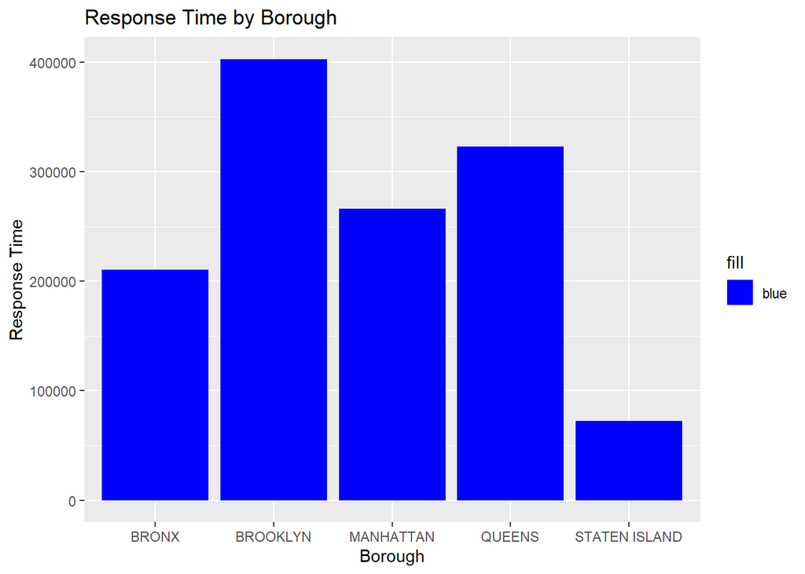

```r
#Plot 4
dfa %>%
    ggplot(aes(x=Borough,fill='blue')) +
    geom_bar() +
    labs(title = "Response Time by Borough",
         x = "Borough",
         y = "Response Time") +
    scale_fill_manual(values = "blue")
```

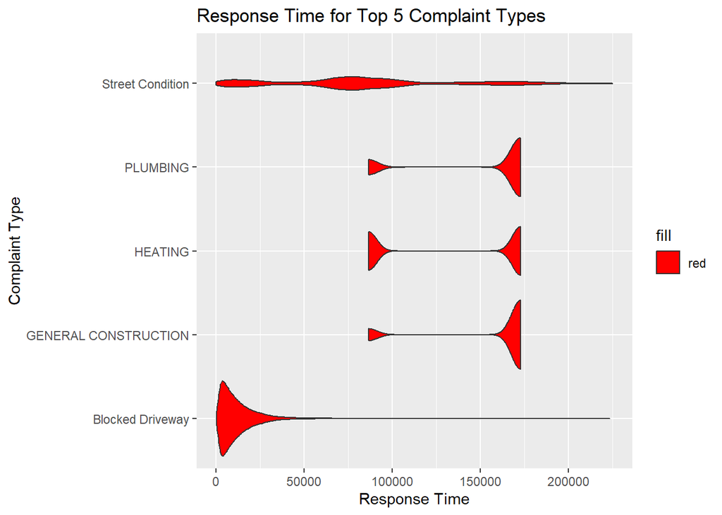

```r
#Plot 5
dfx <- subset(df,ComplaintType %in% c("HEATING","GENERAL CONSTRUCTION","Street Condition","Blocked Driveway","PLUMBING"))

dfx %>%
    ggplot(aes(x=ComplaintType,y=responsetime,group=ComplaintType,fill='red')) +
    geom_violin(scale = "area") +
    labs(title = "Response Time for Top 5 Complaint Types",
         x = "Complaint Type",
         y = "Response Time") +
    coord_flip() +
    ylim(0,225000) +
    scale_fill_manual(values = "red")
```

This violin plot shows that for a Complaint type of Blocked Driveway, there is a large density of entries with a relatively low response time. Also, Street Condition seems to have no trend in response time, and response time for the other complaint types are very similar.

## Part 3: Regression

```r
dfR <- select(df,Agency,ComplaintType,Descriptor,Borough,IncidentZip,responsetime)

dfR <- dfR |> drop_na()

dfR$Agency <- as.factor(dfR$Agency)
dfR$ComplaintType <- as.factor(dfR$ComplaintType)
dfR$Descriptor <- as.factor(dfR$Descriptor)
dfR$Borough <- as.factor(dfR$Borough)
dfR$IncidentZip <- as.factor(dfR$IncidentZip)
```

I make a new data frame for Regression and convert relevant columns to Factor.

```r
#Trial Regression Model
with(dfR,summary(lm(responsetime~Agency)))
```

```
Call:
lm(formula = responsetime ~ Agency)

Residuals:
      Min        1Q    Median        3Q       Max
-15231044   -748546   -489346      1269 266732310

Coefficients:
            Estimate Std. Error t value             Pr(>|t|)
(Intercept)   559261     112363   4.977          0.000000645 ***
AgencyDCA   14672133     122635 119.640 < 0.0000000000000002 ***
AgencyDEP      38352     114044   0.336              0.73665
AgencyDFTA   1592693     416157   3.827              0.00013 ***
AgencyDHS    -559219     299596  -1.867              0.06196 .
AgencyDOB    4823097     115530  41.748 < 0.0000000000000002 ***
AgencyDOE    4194399     188455  22.257 < 0.0000000000000002 ***
AgencyDOF    -264100     163767  -1.613              0.10682
AgencyDOHMH  1857046     119752  15.507 < 0.0000000000000002 ***
AgencyDOITT  2321983     260294   8.921 < 0.0000000000000002 ***
AgencyDOT     289152     113607   2.545              0.01092 *
AgencyDPR    6119552     115886  52.807 < 0.0000000000000002 ***
AgencyDSNY    274930     114323   2.405              0.01618 *
AgencyEDC    3608169     256385  14.073 < 0.0000000000000002 ***
AgencyFDNY   -108257     153398  -0.706              0.48036
AgencyHPD     448485     112862   3.974          0.000070753 ***
AgencyNYPD   -546020     113454  -4.813          0.000001489 ***
AgencyTLC    3978626     122716  32.421 < 0.0000000000000002 ***
---
Signif. codes:  0 '***' 0.001 '**' 0.01 '*' 0.05 '.' 0.1 ' ' 1

Residual standard error: 7421000 on 1419937 degrees of freedom
Multiple R-squared:  0.09732,   Adjusted R-squared:  0.09731
F-statistic:  9005 on 17 and 1419937 DF,  p-value: < 0.00000000000000022
```

This linear model was based on my hypothesis that Agency influences response time. Based on the R-Squared value of 9 percent for such a large data set, Agency is a variable that influences response time.

```r
#Best Regression Model
with(dfR,summary(lm(responsetime~Agency+ComplaintType+Borough)))
```

```
Call:
lm(formula = responsetime ~ Agency + ComplaintType + Borough)

Residuals:
      Min        1Q    Median        3Q       Max
-93263357   -708614   -174524    184971 263845805

Coefficients: (11 not defined because of singularities)
                                                       Estimate Std. Error
(Intercept)                                            97933438    3949541
AgencyDCA                                             -82475752    3949803
AgencyDEP                                             -98446382    3334546
AgencyDFTA                                            -92223540    4303523
AgencyDHS                                             -97766485    3958828
AgencyDOB                                             -84508377    4120655
AgencyDOE                                             -85272195    4016872
AgencyDOF                                             -97543703    3951934
AgencyDOHMH                                           -96099655    3349049
AgencyDOITT                                           -94896892    3956169
AgencyDOT                                             -96432041    1451996
AgencyDPR                                             -84885152    5489331
AgencyDSNY                                            -97481911    4112586
AgencyEDC                                             -93577146    3955931
AgencyFDNY                                            -87065810    5361538
AgencyHPD                                             -97384665    3954609
AgencyNYPD                                           -103082878    4136379
AgencyTLC                                             -97789186    3978231
ComplaintTypeAir Quality                                1207710    2127717
ComplaintTypeAnimal Abuse                               5375129    1236916
ComplaintTypeAnimal Facility - No Permit                -301456    2287077
ComplaintTypeAnimal in a Park                         -12608868    5124195
ComplaintTypeAPPLIANCE                                  1093306     215549
ComplaintTypeAsbestos                                    747746    2116506
ComplaintTypeBeach/Pool/Sauna Complaint                   35916    2156577
ComplaintTypeBEST/Site Safety                         -10384561    3624676
ComplaintTypeBike Rack Condition                        4272103    3739235
ComplaintTypeBike/Roller/Skate Chronic                  5304323    1274235
ComplaintTypeBlocked Driveway                           5489223    1229559
ComplaintTypeBoilers                                   -3438319    3621054
ComplaintTypeBottled Water                               744349    2674024
```

[output cut: 613 more lines]

```
ComplaintTypeWATER LEAK                                                NA
ComplaintTypeWater Quality                                       0.351092
ComplaintTypeWater System                                        0.565275
ComplaintTypeX-Ray Machine/Equipment                                   NA
BoroughBROOKLYN                                      < 0.0000000000000002 ***
BoroughMANHATTAN                                                 0.006432 **
BoroughQUEENS                                        < 0.0000000000000002 ***
BoroughSTATEN ISLAND                                 < 0.0000000000000002 ***
BoroughUnspecified                                               0.004215 **
---
Signif. codes:  0 '***' 0.001 '**' 0.01 '*' 0.05 '.' 0.1 ' ' 1

Residual standard error: 7252000 on 1419749 degrees of freedom
Multiple R-squared:  0.1381,    Adjusted R-squared:  0.138
F-statistic:  1110 on 205 and 1419749 DF,  p-value: < 0.00000000000000022
```

After running many trial and error linear models using different variable combinations, the best regression model I came up with includes the variables Agency, ComplaintType and Borough. These are the variables that affect the response time the most. My R squared value of 14%, for such a large data set, supports my claim.

## Part 4: Regression Diagnostics

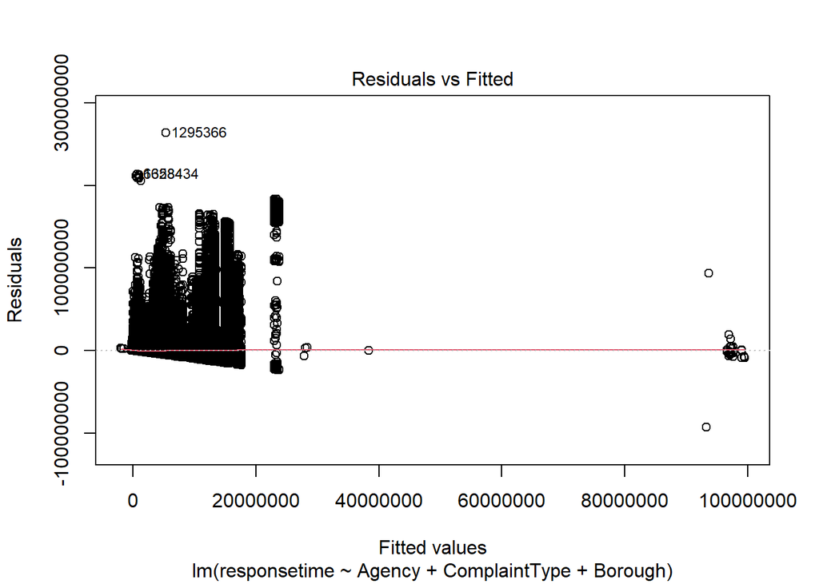

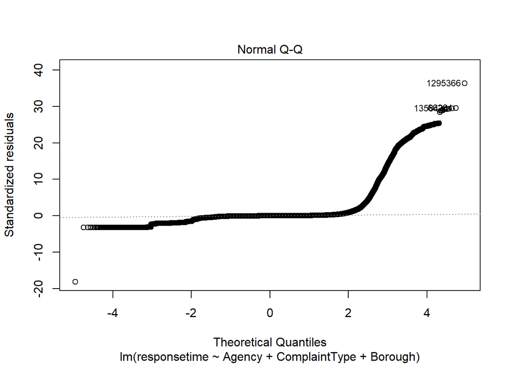

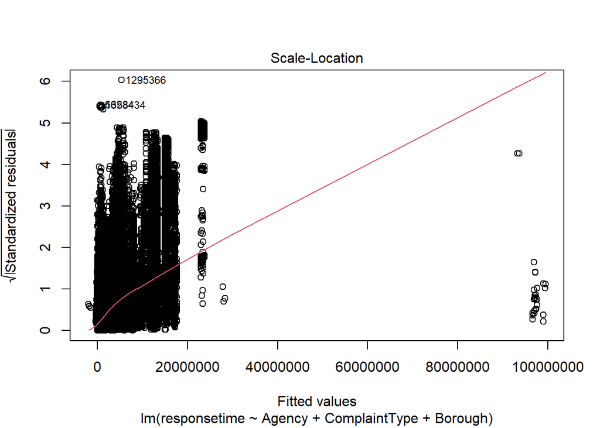

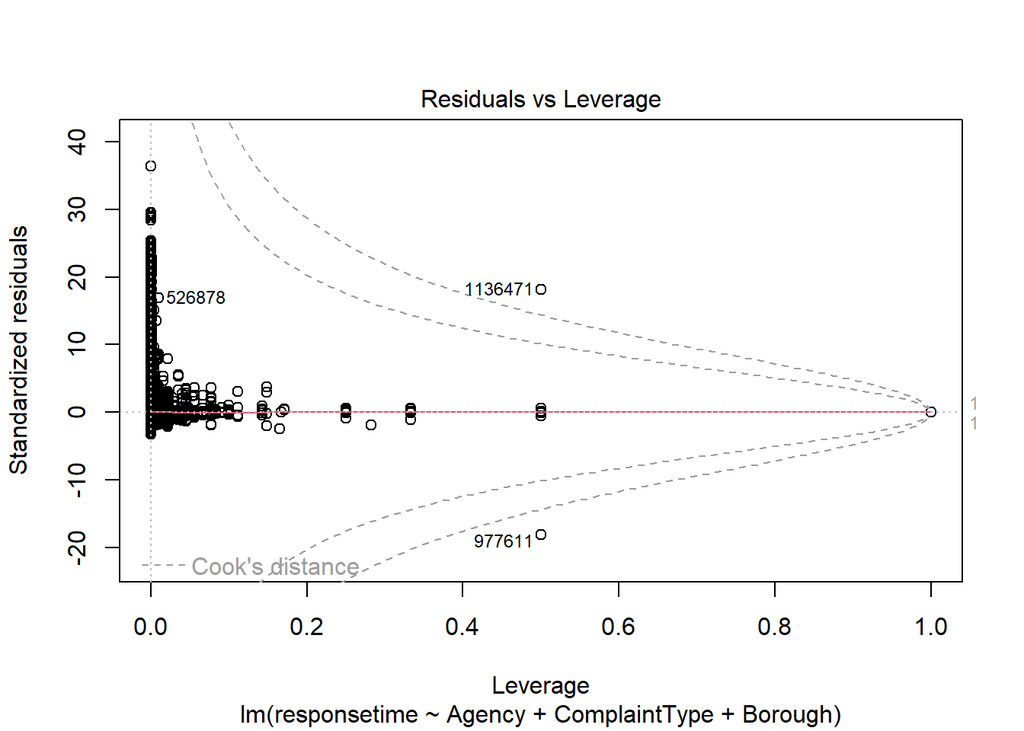

```r
model<-(lm(responsetime~Agency+ComplaintType+Borough,data=dfR))

plot(model)
```

Normal Q-Q: In this instance, the residuals do not comply with the dashed line at all, instead trailing at the start and spiking upwards in value as the line continues. Therefore, we can assume that the residuals are not normally distributed.

Scale Location: Here, the red line is an upwards slope, meaning that there is large variability in the standardized residuals - violation of the assumption of constant variance, also known as homoscedasticity.

Final Conclusion: In Summary, after a thorough analysis of the New York 311 calls data set, I believe the variables that affect the response time of a complaint are the Borough, the type of complaint and the agency handling the complaint. Other variables like IncidentZip seem to have little to no affect on the values of response time.